# Simplex Algorithm

First, we import the packages we need. Numpy will help with dealing with arrays.

```python
import numpy as np
import math
import time
```

A function is needed to take max $(cx)$ subject to $Ax \leq b, x \geq 0$ and convert it to standard form: max $(c'x)$ subject to $A'x = b', x \geq 0.$

```python
def standard_form(A,b,c):
    N = A.shape[0]
    M = A.shape[1]
    A = np.hstack((A,np.eye(N)))
    c = np.hstack((c,np.zeros(N)))
    for i in range(N):
        if b[i] < 0:
            b[i] = -1*b[i]
            A[i] = -1*A[i]
    return A, b, c
```

Next, we need a function that will take the arrays and create the initial tableau.

```python
def create_table(A,b,c):
    Z_col = np.zeros(b.shape)
    A_prime = np.hstack((A, Z_col))
    c_prime = np.hstack((-c, np.array([1, 0])))
    table = np.vstack((np.hstack((A_prime, b)),c_prime))
    return table
```

To iterate through the Simplex Algorithm, we need to find the pivots at each iteration for the given tableau.

```python
def find_pivot(table):
    last_row = table[table.shape[0]-1]
    last_row = last_row[:-1]
    min_value_r = min(last_row)
    pivot_col = last_row.tolist().index(min_value_r)
    ratios = [table[i][table.shape[1]-1] / table[i][pivot_col] if table[i][pivot_col] != 0 else math.inf
              for i in range(table.shape[0]-1)]
    min_value_c = min(ratios)
    pivot_row = ratios.index(min_value_c)
    return(pivot_row, pivot_col)
```

Once the pivot is found, we need to perform the row operations in the tableau that constitute a move.

```python
def move(table, pivot_row, pivot_col):
    pivot_value = table[pivot_row][pivot_col]
    table[pivot_row] = table[pivot_row]/pivot_value
    loop_rows = [i for i in range(table.shape[0]) if i != pivot_row]
    for i in loop_rows:
        new_val = table[i][pivot_col]
        table[i] = table[i] - new_val*table[pivot_row]
    return table
```

In order to know when we have arrived at a solution and need to terminate, we need a function that will check the tableau to see if we need to iterate again or terminate.

```python
def check(table):
    last_row = table[table.shape[0]-1]
    last_row = last_row[:-1]
    return not all(i >= 0 for i in last_row)
```

Once we have arrived at a solution, we need to find the basic and non-basic columns in our tableau. This will allow us to derive the optimal values of each decision variable. The optimal objective value will be in the lower right corner of the tableau.

```python
def read_solution(table):
    optimal_value = table[-1][-1]
    solution_vector = []
    orig_c = table[:,-1]
    orig_c = orig_c[:-1]
    for i in range(table.shape[1]):
        curr_col = table[:,i].tolist()
        remove_zeros = list(filter(lambda a: a != 0, curr_col))
        if remove_zeros == [1]:
            #these are the basic variables
            basic_col = np.array(curr_col)
            basic_col = basic_col[:-1]
            solution_vector.append(np.dot(orig_c,basic_col))
        else:
            #these are the non-basic variables
            solution_vector.append(0)
    return optimal_value, solution_vector
```

Now we have everything we need to solve a linear program using the Simplex algorithm! Let's try it out with this example problem.

"Suppose you have 2 production plants for making furniture. Due to specifications, each plant's operations are different in terms of labor needed, materials, and pollution produced per car. These are summarized for each plant for one unit of furniture produced:

Plant 1: 2 labor, 2 materials, 13 pollution Plant 2: 3 labor, 4 materials, 9 pollution

We have 200 hours of labor and 250 units of material available. We do not want to produce more than 900 units of pollution. The goal is to maximize the total amount of furnature produced between all the plants."

We can formulate this as a linear programming model.

Decision Variables: Let $x_i$ = the number of furnature produced at plant i.

Constraints: We have 200 hours of labor $$2*x_1 + 3*x_2 \leq 200$$ We have 250 units of material available: $$2*x_1 + 4*x_2 \leq 250$$ We are allowed to produce 900 units of pollution $$13*x_1 + 9*x_2 \leq 900$$ We cannot produce a negative amount of furniture $$x_i \geq 0; \forall i$$

Objective Function: Maximize the number of furniture produced: $$x_1 + x_2$$

```python
A = np.array([[2, 3],
              [2, 4],
              [13, 9]])
b = np.array([[200],
              [250],
              [900]])
c = np.array([1, 1])
```

Now we can convert the arrays into standard form, create the tableau, find the pivot, move to the next vertex, iterate until finding a solution, then reporting the solution!

```python
start_time = time.time()
A, b, c = standard_form(A,b,c)
table = create_table(A,b,c)
iters = 0
max_iters = 1000
proceed = True
while proceed and iters < max_iters:
    pivot_row, pivot_col = find_pivot(table)
    table = move(table, pivot_row, pivot_col)
    proceed = check(table)
    iters += 1
if iters == max_iters:
    print("Solution not found")
else:
    optimal_value, solution_vector = read_solution(table)
    total_time = time.time() - start_time
    print("Optimal solution found in " + str(iters) + " iterations in " + str(total_time) + " seconds")
    print("The optimal objective value is: " + str(optimal_value))
    print("The optimal solution vector for the decision variables is:")
    print(solution_vector)
```

```
Optimal solution found in 2 iterations in 0.0009970664978027344 seconds
The optimal objective value is: 80.95238095238095
The optimal solution vector for the decision variables is:
[42.85714285714285, 38.0952380952381, 0, 11.904761904761898, 0, 0.0, 0]
```

Thus, the optimal solution is for factory 1 to produce 42.9 units of furniture and for factory 2 to produce 38.1 units of furniture. The Simplex algorithm is extremely fast in finding a solution, but obviously fractional pieces of furniture does not make sense in a practical world. Thus, the Simplex algorithm is very effective at solving LP's.

# Sudoku Solver

Problem Description: Given a 9 x 9 grid with some numbers already given, each row, column, and 3 x 3 sub-grid must have exactly one of each numbers from 1 to 9.

Solution Method: Binary Integer Program using Python. The first solver uses CPLEX, and the second solver uses Gurobi.

# 1) Solving with CPLEX

## Step 1.1: Import Packages and Store Given Sudoku Grid

The grid will be stored as a Numpy Array, where the empty cells will be denoted with a zero. The grid can be initialized by calling a file or explicitly forming it.

```python
from docplex.mp.model import Model
from docplex.util.environment import get_environment
import numpy as np
from numpy import genfromtxt
import pandas as pd
import time
```

```python
# read csv sudoku grid
#GRID = genfromtxt("sudoku_grid1.csv", delimiter=',')

# or directly declare grid
GRID = np.array([[8, 7, 6, 9, 0, 0, 0, 0, 0],
                 [0, 1, 0, 0, 0, 6, 0, 0, 0],
                 [0, 4, 0, 3, 0, 5, 8, 0, 0],
                 [4, 0, 0, 0, 0, 0, 2, 1, 0],
                 [0, 9, 0, 5, 0, 0, 0, 0, 0],
                 [0, 5, 0, 0, 4, 0, 3, 0, 6],
                 [0, 2, 9, 0, 0, 0, 0, 0, 8],
                 [0, 0, 4, 6, 9, 0, 1, 7, 3],
                 [0, 0, 0, 0, 0, 1, 0, 0, 4]])
```

## Step 1.2: Build CPLEX Binary Integer Program

```python
def build_sudoku_model_cplex(grid, **kwargs):
    # create model
    m = Model(name='Sudoku', **kwargs)
    # create variables
    # x(i,j,k) = 1 if number k is in row i col j
    v  = {(i,j,k): m.binary_var(name="x_{0}_{1}_{2}".format(i,j,k)) for i in range(9) for j in range(9) for k in range(9)}

    # constrain given numbers
    for i in range(9):
        for j in range(9):
            if grid[i][j] != 0:
                c = m.add_constraint(v[i,j,grid[i][j]-1] == 1)

    # constrain each cell to have one number
    for i in range(9):
        for j in range(9):
            m.add_constraint(m.sum(v[i,j,k] for k in range(9)) == 1)

    # constrain each column to have one of each number
    for j in range(9):
        for k in range(9):
            m.add_constraint(m.sum(v[i,j,k] for i in range(9)) == 1)

    # constrain each row to have one of each number
    for i in range(9):
        for k in range(9):
            m.add_constraint(m.sum(v[i,j,k] for j in range(9)) == 1)

    # constrain each 3x3 box to have one of each number
    for a in range(3):
        for b in range(3):
            for k in range(9):
                box_row = [3*a, 3*a+1, 3*a+2]
                box_col = [3*b, 3*b+1, 3*b+2]
                m.add_constraint(m.sum(v[i,j,k] for i in box_row
                                       for j in box_col) == 1)

    # arbitrary objective funcion
    m.minimize(1)
    return m, v
```

## Step 1.3: Function for Printing Solution

```python
def print_solution(variables):
    # create pandas df to store solution and print solution
    opt_df = pd.DataFrame.from_dict(variables, orient="index", columns = ["variable_object"])
    opt_df.index = pd.MultiIndex.from_tuples(opt_df.index, names=["i", "j", "k"])
    opt_df.reset_index(inplace=True)
    opt_df["solution_value"] = opt_df["variable_object"].apply(lambda item: item.solution_value)
    solution = np.zeros((9,9))
    for i, row in opt_df.iterrows():
        if row["solution_value"] == 1:
            solution[int(row["i"])][int(row["j"])] = int(row["k"]) + 1
    print(solution)
```

## Step 1.4: Run, Solve, and Print Solution

```python
if __name__ == '__main__':
    # Build the model
    start_time = time.time()
    model, variables = build_sudoku_model_cplex(GRID)
    model.print_information()
    # Solve the model.
    if model.solve():
        t = time.time() - start_time
        print("Solution Found in " + str(t) + " seconds.")
        print_solution(variables)
    else:
        print("Sudoku grid given has no solution")
```

```
Model: Sudoku
 - number of variables: 729
   - binary=729, integer=0, continuous=0
 - number of constraints: 354
   - linear=354
 - parameters: defaults
 - objective: none
 - problem type is: MILP
Solution Found in 0.07341623306274414 seconds.
[[8. 7. 6. 9. 1. 4. 5. 3. 2.]
 [3. 1. 5. 2. 8. 6. 7. 4. 9.]
 [9. 4. 2. 3. 7. 5. 8. 6. 1.]
 [4. 3. 8. 7. 6. 9. 2. 1. 5.]
 [6. 9. 1. 5. 2. 3. 4. 8. 7.]
 [2. 5. 7. 1. 4. 8. 3. 9. 6.]
 [1. 2. 9. 4. 3. 7. 6. 5. 8.]
 [5. 8. 4. 6. 9. 2. 1. 7. 3.]
 [7. 6. 3. 8. 5. 1. 9. 2. 4.]]
```

# 2) Solving With Gurobi

## Step 2.1: Import Packages and Store Given Sudoku Grid

```python
from gurobipy import *
import numpy as np
from numpy import genfromtxt
import csv
import time

GRID = np.array([[8, 7, 6, 9, 0, 0, 0, 0, 0],
                 [0, 1, 0, 0, 0, 6, 0, 0, 0],
                 [0, 4, 0, 3, 0, 5, 8, 0, 0],
                 [4, 0, 0, 0, 0, 0, 2, 1, 0],
                 [0, 9, 0, 5, 0, 0, 0, 0, 0],
                 [0, 5, 0, 0, 4, 0, 3, 0, 6],
                 [0, 2, 9, 0, 0, 0, 0, 0, 8],
                 [0, 0, 4, 6, 9, 0, 1, 7, 3],
                 [0, 0, 0, 0, 0, 1, 0, 0, 4]])
```

## Step 1.2: Build Gurobi Binary Integer Program

```python
def build_sudoku_model_gurobi(grid):

    m = Model("Solve_Sudoku")

    # Add Binary Variables
    # x_i,j,k = 1 if cell in row i column j is number k
    rows = range(9)
    columns = range(9)
    numbers = range(9)

    v = m.addVars(rows, columns, numbers, vtype = GRB.BINARY, name = 'v')

    # Assign values for filled in cells
    for i in rows:
        for j in columns:
            if GRID[i][j] != 0:
                v[i,j,GRID[i][j]-1].lb = 1

    # Each cell contains one number
    each_cell = m.addConstrs(v.sum(i,j,'*') == 1 for i in rows for j in columns)

    # Each row has one of each number
    each_row = m.addConstrs(quicksum([v[i,j,k] for j in columns])
    == 1 for i in rows for k in numbers)

    # Each column has one of each number
    each_col = m.addConstrs(quicksum([v[i,j,k] for i in rows])
    == 1 for j in columns for k in numbers)

    # Each box has one of each number
    for a in range(3):
        for b in range(3):
            box_row = [3*a, 3*a+1, 3*a+2]
            box_col = [3*b, 3*b+1, 3*b+2]
            each_box = m.addConstrs(quicksum([v[i,j,k] for i in box_row
                                              for j in box_col]) == 1 for k in numbers)
    return m, v, GRID
```

## Step 1.3: Function for Printing Solution

```python
def print_solution(m, GRID):
    index = []
    for z in m.getVars():
        if z.x == 1:
            index.append(z.varName)
    for c in range(len(index)):
        new_list = list(str(index[c]))
        i = int(new_list[2])
        j = int(new_list[4])
        k = int(new_list[6])
        GRID[i][j] = k + 1
    print(GRID)
```

## Step 1.4: Run, Solve, and Print Solution

```python
if __name__ == '__main__':
    # Build the model
    start_time = time.time()
    model, variables, GRID = build_sudoku_model_gurobi(GRID)
    model.update()
    # Solve the model
    model.optimize()
    t = time.time() - start_time
    print("Solution Found in " + str(t) + " seconds.")
    print_solution(model, GRID)
```

```
Optimize a model with 324 rows, 729 columns and 2916 nonzeros
Variable types: 0 continuous, 729 integer (729 binary)
Coefficient statistics:
  Matrix range     [1e+00, 1e+00]
  Objective range  [0e+00, 0e+00]
  Bounds range     [1e+00, 1e+00]
  RHS range        [1e+00, 1e+00]
Presolve removed 324 rows and 729 columns
Presolve time: 0.00s
Presolve: All rows and columns removed

Explored 0 nodes (0 simplex iterations) in 0.01 seconds
Thread count was 1 (of 4 available processors)

Solution count 1: 0

Optimal solution found (tolerance 1.00e-04)
Best objective 0.000000000000e+00, best bound 0.000000000000e+00, gap 0.0000%
Solution Found in 0.02991938591003418 seconds.
[[8 7 6 9 1 4 5 3 2]
 [3 1 5 2 8 6 7 4 9]
 [9 4 2 3 7 5 8 6 1]
 [4 3 8 7 6 9 2 1 5]
 [6 9 1 5 2 3 4 8 7]
 [2 5 7 1 4 8 3 9 6]
 [1 2 9 4 3 7 6 5 8]
 [5 8 4 6 9 2 1 7 3]
 [7 6 3 8 5 1 9 2 4]]
```

# Solving the Cutting Stock Problem with Column Generation

```python
from gurobipy import *
import gurobipy as grb
from gurobipy import GRB
import numpy as np

def cuttingstock(patterns, demands, raw, finals):
    # Solves cutting stock problem (prints solution)
    # Inputs:
    #   patterns: list of lists containing initial patterns
    #   demands: list of demands
    #   raw: length of raw
    #   finals: list of lengths of finals

    # initialize pi_val to be more than 1
    pi_val = 10

    # initialize iteration count
    iterations = 0

    # while pricing problem has obj value > 1
    while pi_val > 1:
        # create restricted master problem
        m_RMP = Model("Restricted Master Problem")
        m_RMP.Params.outputFlag = 0
        num_cols = len(patterns[0])
        cols = range(num_cols)
        num_rows = len(patterns)
        rows = range(num_rows)

        # create variables x
        x = m_RMP.addVars(cols, name = "x", lb = 0)

        # create constraints in Ax >= b form
        for i in rows:
            expr = grb.LinExpr()
            for j in cols:
                expr += patterns[i][j]*x[j]
            m_RMP.addConstr(expr, GRB.GREATER_EQUAL, demands[i])

        # update and write for sanity check
        m_RMP.update()
        m_RMP.write("cuttingstock.lp")

        # create objective function
        m_RMP.setObjective(grb.quicksum(x[j] for j in cols))

        # solve
        m_RMP.optimize()

        # gurobi finds dual values
        y = m_RMP.getAttr("Pi", m_RMP.getConstrs())

        # create pricing problem
        m_knap = Model("Knapsack Pricing Problem")

        m = len(y)
        M = range(m)

        # create pricing variables
        pi = m_knap.addVars(M, vtype = GRB.INTEGER, name = "pi", lb = 0)

        # create objective function
        m_knap.setObjective(grb.quicksum(y[i]*pi[i] for i in M), GRB.MAXIMIZE)

        # add knapsack constraint
        m_knap.addConstr(grb.quicksum(finals[i]*pi[i] for i in M) <= raw)

        # update and write for sanity check
        m_knap.update()
        m_knap.write("knap.lp")

        m_knap.Params.outputFlag = 0

        # solve
        m_knap.optimize()

        # obtain objective value
        pi_obj = m_knap.getObjective()
        pi_val = pi_obj.getValue()

        # iteration count
        iterations += 1

        # add new best pattern to pattern array
        for i in rows:
            patterns[i].append(pi[i].x)

    # now optimal, print solution to cutting stock
    optimal = m_RMP.getObjective()
    optimal_value = optimal.getValue()
    pattern_array = np.array(patterns)
    for i in cols:
        if x[i].x > 0:
            print("Cut %f raws with pattern:" % (x[i].x))
            print(pattern_array[:,i])
    print("For a total of %f raws used and %d iterations" % (optimal_value, iterations))
```

```python
initial_patterns = [[1,0,0,0],[0,1,0,0],[0,0,1,0],[0,0,0,1]]
demands = [97,610,395,211]
raw = 104
finals = [45, 36, 31, 14]
cuttingstock(initial_patterns, demands, raw, finals)
```

```
Academic license - for non-commercial use only
Cut 3.928571 raws with pattern:
[-0. -0. -0.  7.]
Cut 305.000000 raws with pattern:
[-0.  2.  1.  0.]
Cut 48.500000 raws with pattern:
[ 2. -0. -0.  1.]
Cut 45.000000 raws with pattern:
[ 0. -0.  2.  3.]
For a total of 402.428571 raws used and 6 iterations
```

# Eight (N) Queens Problem

Problem Description: Place eight (or N) queens on an 8 by 8 (or N by N) chess board in such a way that all the queens do not "attack" any other queen.

Solution Method: Binary Integer Program using Python and Gurobi

# # Step 1: Import Packages

```python
from gurobipy import *
import gurobipy as grb
from gurobipy import GRB
import time
```

# # Step 2: Build Binary Integer Program

```python
def build_eight_queens(n):
    # create model
    Q = Model("Queens")
    N = range(n)

    # create variables
    x = Q.addVars(N,N,vtype = GRB.BINARY, name = "x")

    # contrain such that no queen attacks another

    #1) one queen per row
    Q.addConstrs(grb.quicksum(x[i,j] for j in N) == 1 for i in N)
    #2) one queen per column
    Q.addConstrs(grb.quicksum(x[i,j] for i in N) == 1 for j in N)
    #3) exactly n queens on board
    Q.addConstr(grb.quicksum(x[i,j] for i in N for j in N) == n)
    #4) one queen per diagnoal
    Q.addConstrs(grb.quicksum(x[i+k,i] for i in range(n-k)) <= 1 for k in N)
    Q.addConstrs(grb.quicksum(x[i,i+k] for i in range(n-k)) <= 1 for k in N)
    Q.addConstrs(grb.quicksum(x[i+k,n-i-1] for i in range(n-k)) <= 1 for k in range(n))
    Q.addConstrs(grb.quicksum(x[i,n-i-k-1] for i in range(n-k)) <= 1 for k in range(n))
    #5) arbitrary objective function
    Q.setObjective(0)

    return Q, x
```

# # Step 3: Function for Printing Solution

```python
def print_solution(x,N):
    for i in N:
        line = ""
        for j in N:
            if x[i,j].x > 0.1:
                line = line + "Q "
            else:
                line = line + ". "
        print(line)
```

# # Step 4: Run, Solve, and Print Solution

```python
if __name__ == '__main__':
    # Build the model
    for n in [8, 10, 20, 30]:
        start_time = time.time()
        model, variables = build_eight_queens(n)
        model.setParam("OutputFlag", 0)
        model.optimize()
        status = model.status
        # Solve the model
        t = time.time() - start_time
        print("Solution for Board Size "+ str(n) +" Found in " + str(t) + " seconds.")
        print_solution(variables,range(n))
        print()
```

```
Solution for Board Size 8 Found in 0.008981704711914062 seconds.
. . . . Q . . .
. . . . . . Q .
. Q . . . . . .
. . . . . Q . .
. . Q . . . . .
Q . . . . . . .
. . . . . . . Q
. . . Q . . . .

Solution for Board Size 10 Found in 0.008973836898803711 seconds.
. . . . . Q . . . .
. . . Q . . . . . .
. Q . . . . . . . .
. . . . . . . . . Q
. . . . . . . Q . .
. . Q . . . . . . .
Q . . . . . . . . .
. . . . . . . . Q .
. . . . . . Q . . .
. . . . Q . . . . .

Solution for Board Size 20 Found in 0.01695418357849121 seconds.
. . . . . . . . Q . . . . . . . . . . .
. . . . . Q . . . . . . . . . . . . . .
. . . . . . . . . . . . Q . . . . . . .
. . . . . . . . . . . . . . . . . . Q .
. . . . . . . . . . . . . Q . . . . . .
. . . . . . . . . . Q . . . . . . . . .
. . . . . . . . . . . . . . . . . Q . .
. . . . Q . . . . . . . . . . . . . . .
. . . . . . . . . . . . . . Q . . . . .
. Q . . . . . . . . . . . . . . . . . .
. . . Q . . . . . . . . . . . . . . . .
. . . . . . . . . Q . . . . . . . . . .
. . . . . . Q . . . . . . . . . . . . .
. . . . . . . . . . . . . . . Q . . . .
. . Q . . . . . . . . . . . . . . . . .
. . . . . . . . . . . Q . . . . . . . .
. . . . . . . . . . . . . . . . . . . Q
```

[output cut: 20 more lines]

```
. . Q . . . . . . . . . . . . . . . . . . . . . . . . . . .
. . . . . . Q . . . . . . . . . . . . . . . . . . . . . . .
. . . . . . . . . . . . . . . . . . Q . . . . . . . . . . .
. Q . . . . . . . . . . . . . . . . . . . . . . . . . . . .
. . . . . . . . . . . . Q . . . . . . . . . . . . . . . . .
. . . . . . . . . Q . . . . . . . . . . . . . . . . . . . .
. . . . . . . . . . . . . . . . . . . . . . . . . Q . . . .
. . . . . . . . . . . . . . . . . . . Q . . . . . . . . . .
. . . Q . . . . . . . . . . . . . . . . . . . . . . . . . .
. . . . . . . . . . . . . . . . . . . . . . . Q . . . . . .
. . . . . . . Q . . . . . . . . . . . . . . . . . . . . . .
. . . . Q . . . . . . . . . . . . . . . . . . . . . . . . .
. . . . . . . . . . . . . . . . . . . . . Q . . . . . . . .
. . . . . . . . . . . . . . . . . . . . . . . . . . . . Q .
. . . . . . . . . . . . . . . Q . . . . . . . . . . . . . .
```

# Sweep Heuristic for the Vehicle Routing Problem

Problem Description: Given a set of customers and a fixed number of trucks, find the truck routes that minimizes the total distance traveled such that between all the trucks, each customer is visited.

Import packages

```python
import math
import numpy as np
import matplotlib.pyplot as plt
import time
```

Function that takes cartesian coords and returns polar coords

```python
def cart2pol(x, y):
    rho = np.sqrt(x**2 + y**2)
    phi = np.arctan2(y, x)
    return(rho, phi)
```

Function that takes cartesian coords and returns distance between the two

```python
def distance(x,y):
    return math.sqrt(sum([(a - b) ** 2 for a, b in zip(x, y)]))
```

Define the Sweep Function

```python
def sweepVRP(instance):
    # start time and read in .tsp file of instance provided
    # two different formats for instances:
    start_time = time.time()
    infile = open(instance, 'r')
    infile.readline()
    if instance == "bier127.tsp":
        N = int(infile.readline().strip().split()[2])
        for i in range(4):
            infile.readline()
    elif instance == "berlin52.tsp" or instance == "ch150.tsp":
        infile.readline()
        N = int(infile.readline().strip().split()[1])
        for i in range(3):
            infile.readline()

    # create lists to store nodes, locations, and if visited
    nodelist = [infile.readline().strip().split() for i in range(N)]
    nodelist = [[int(nodelist[i][0])-1,float(nodelist[i][1]),float(nodelist[i][2])] for i in range(len(nodelist))]
    location = [(float(nodelist[i][1]),float(nodelist[i][2])) for i in range(N)]
    visited = [False for i in range(N)]
    visited[0] = True

    # displace coordinates with v0 as origin
    home_cart = location[0]
    new_location = [(location[i][0]-home_cart[0], location[i][1]-home_cart[1]) for i in range(len(location))]

    # convert coords to polar
    polar = []
    for i in range(len(new_location)):
        polar.append(cart2pol(new_location[i][0],new_location[i][1]))

    # def k' and b as defined in assignment
    k_prime = math.ceil(math.sqrt(N-1))
    b = k_prime
    k = 1

    # start loop by visiting visiting next node based off smallest clockwise angle to current node
    trucks = []
    d = 0
    # loop for each truck and for when we have unvisited nodes
    while all(visited) == False and k < k_prime:
        # find nodes and polar coords that are unvisited to consider
        indices = [i for i, x in enumerate(visited) if x == False]
        unvisit_polar = [polar[i] for i in indices]
        combined = [(indices[i],unvisit_polar[i][1]) for i in range(len(indices))]
        angles = [polar[i][1] for i in indices]
        closest = min(angles, key=lambda x:abs(x-(math.pi*2)))
        s = angles.index(closest)
        cur = combined[s][0]
        cur_angle = combined[s][1]
        count = 1
        visited[cur] = True
        route = [cur]
        # calc distance from home city to first node
        d += distance(location[0],location[cur])

        # loop for single truck while under b limit and have unvisited
        while count < b and all(visited) == False:
            # find node closest to cur by smallest angle change clockwise
            # move to this node and calc distance
            old_cur = cur
            indices = [i for i, x in enumerate(visited) if x == False]
            unvisit_polar = [polar[i] for i in indices]
            combined = [(indices[i],unvisit_polar[i][1]) for i in range(len(indices))]
            angles = [polar[i][1] for i in indices]
            displaced_angles = [cur_angle - angles[i] for i in range(len(angles))]
            for i in range(len(displaced_angles)):
                if displaced_angles[i] < 0:
                    displaced_angles[i] = 10
            closest = min(angles, key=lambda x:abs(x-(cur_angle)))
            s = angles.index(closest)
            cur = combined[s][0]
            cur_angle = combined[s][1]
            count += 1
            visited[cur] = True
            route.append(cur)
            d += distance(location[old_cur],location[cur])

        # add distance from end node for truck back to home city
        d += distance(location[cur],location[0])
        k += 1
        trucks.append(route)
        t = time.time() - start_time
    return(trucks,t,d,new_location)
```

Function for printing the solution

```python
def plot_solution(new_location, trucks, instance):
    for j in range(len(trucks)):
        x = [new_location[i][0] for i in trucks[j]]
        y = [new_location[i][1] for i in trucks[j]]
        plt.scatter(x, y)
    plt.scatter(0,0,marker = '^',color = "black", label = "home")
    plt.title(instance + " sweep hueristic")
    plt.axis('off')
    plt.show()
```

Test instances of TSP can be found at: http://elib.zib.de/pub/mp-testdata/tsp/tsplib/tsp/index.html Each color represents one truck's assigned customer. The black triangle is the depot.

Run and solve Berlin52 Instance

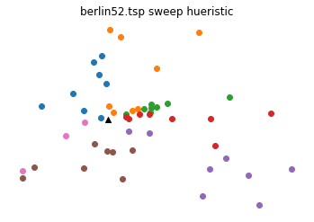

```
-- berlin52.tsp sweep solution --
berlin52 solution found in 0.007978 seconds with distance 20759.628277
Truck 0 visits customers:
[16, 21, 17, 2, 40, 18, 7, 44]
Truck 1 visits customers:
[8, 31, 9, 48, 42, 32, 38, 39]
Truck 2 visits customers:
[14, 37, 35, 3, 4, 5, 50, 23]
Truck 3 visits customers:
[36, 34, 47, 10, 33, 24, 11, 27]
Truck 4 visits customers:
[51, 45, 26, 12, 25, 43, 13, 46]
Truck 5 visits customers:
[15, 28, 49, 19, 29, 22, 1, 41]
Truck 6 visits customers:
[6, 20, 30]
```

```python
b52, t52, d52, n52 = sweepVRP("berlin52.tsp")
plot_solution(n52, b52, "berlin52.tsp")
print("-- berlin52.tsp sweep solution --")
print("berlin52 solution found in %f seconds with distance %f" % (t52,d52))
for i in range(len(b52)):
    print("Truck %g visits customers:" %(i) )
    print(b52[i])
```

Run and solve Bier127 Instance

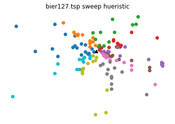

```
-- bier127.tsp sweep solution --
bier127 solution found in 0.018946 seconds with distance 360157.541644
Truck 0 visits customers:
[126, 92, 102, 43, 44, 106, 53, 93, 1, 56, 110, 47]
Truck 1 visits customers:
[50, 117, 45, 111, 52, 48, 46, 120, 55, 4, 123, 49]
Truck 2 visits customers:
[54, 51, 65, 12, 64, 114, 112, 98, 88, 99, 9, 91]
Truck 3 visits customers:
[63, 57, 119, 124, 6, 90, 2, 60, 61, 89, 103, 59]
Truck 4 visits customers:
[115, 58, 10, 113, 8, 104, 109, 84, 85, 66, 86, 87]
Truck 5 visits customers:
[5, 7, 23, 70, 105, 22, 108, 71, 72, 95, 18, 3]
Truck 6 visits customers:
[107, 69, 67, 14, 21, 73, 68, 20, 118, 16, 17, 19]
Truck 7 visits customers:
[76, 74, 62, 75, 77, 83, 80, 78, 116, 125, 81, 79]
Truck 8 visits customers:
[82, 101, 11, 100, 30, 26, 31, 13, 28, 25, 24, 32]
Truck 9 visits customers:
[29, 121, 27, 37, 40, 38, 33, 97, 96, 42, 41, 122]
Truck 10 visits customers:
[15, 35, 36, 39, 94, 34]
```

```python
b127, t127, d127, n127 = sweepVRP("bier127.tsp")
plot_solution(n127, b127, "bier127.tsp")
print("-- bier127.tsp sweep solution --")
print("bier127 solution found in %f seconds with distance %f" % (t127,d127))
for i in range(len(b127)):
    print("Truck %g visits customers:" %(i) )
    print(b127[i])
```

Run and solve Ch150 Instance

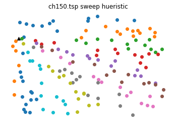

```
-- ch150.tsp sweep solution --
ch150 solution found in 0.017952 seconds with distance 35670.262629
Truck 0 visits customers:
[81, 94, 106, 4, 142, 99, 102, 141, 84, 17, 96, 131, 136]
Truck 1 visits customers:
[64, 74, 49, 101, 54, 69, 134, 57, 107, 113, 85, 25, 98]
Truck 2 visits customers:
[97, 82, 18, 28, 140, 145, 80, 1, 55, 5, 36, 109, 8]
Truck 3 visits customers:
[6, 24, 27, 123, 41, 46, 89, 119, 19, 138, 45, 39, 7]
Truck 4 visits customers:
[50, 91, 83, 52, 137, 92, 125, 53, 108, 32, 117, 23, 35]
Truck 5 visits customers:
[11, 60, 42, 68, 133, 34, 88, 10, 126, 147, 66, 115, 104]
Truck 6 visits customers:
[129, 51, 100, 38, 110, 95, 16, 130, 31, 65, 37, 56, 59]
Truck 7 visits customers:
[40, 22, 29, 76, 132, 116, 139, 15, 121, 128, 58, 13, 143]
Truck 8 visits customers:
[14, 26, 48, 146, 79, 71, 120, 78, 77, 30, 144, 33, 122]
Truck 9 visits customers:
[93, 111, 87, 135, 62, 63, 73, 9, 20, 112, 12, 43, 105]
Truck 10 visits customers:
[70, 47, 114, 149, 44, 90, 127, 124, 118, 67, 148, 3, 61]
Truck 11 visits customers:
[2, 103, 21, 72, 75, 86]
```

```python
ch150, t150, d150, n150 = sweepVRP("ch150.tsp")
plot_solution(n150, ch150, "ch150.tsp")
print("-- ch150.tsp sweep solution --")
print("ch150 solution found in %f seconds with distance %f" % (t150,d150))
for i in range(len(ch150)):
    print("Truck %g visits customers:" %(i) )
    print(ch150[i])
```

# Symmetric Traveling Salesman Problem: A Simple Nearest Neighbor Heuristic

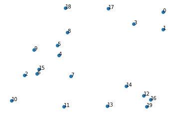

```python
import math
import timeit
import numpy as np
import matplotlib.pyplot as plt
from prettytable import PrettyTable

N = 20
arr = 20*np.random.rand(N,2)

n = range(N)
plt.scatter(arr[:,0], arr[:,1])
plt.axis('off')
for i, txt in enumerate(n):
    plt.annotate(txt, (arr[i,0], arr[i,1]))
```

```python
def distance(x,y):
    return math.sqrt(((x[0]-y[0])**2)+((x[1]-y[1])**2))
```

```python
def nearest_neighbor(N,arr,start):
    visited = [False for i in range(N)]
    visited[start] = True
    location = arr[start]
    total_distance = 0
    route = [start]

    while all(visited) == False:
        not_visited = list(set(range(N))-set(route))
        dist = [distance(location,arr[i]) for i in not_visited]
        distance_dict = {k:v for (k,v) in zip(not_visited,dist)}
        min_index = min(distance_dict.keys(), key=(lambda k: distance_dict[k]))
        visited[min_index] = True
        total_distance += distance_dict[min_index]
        location = arr[min_index]
        route.append(min_index)

    route.append(start)
    total_distance += distance(location,arr[start])
    return(route, total_distance)
```

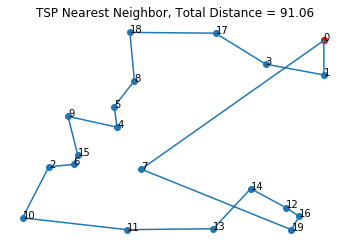

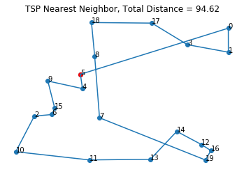

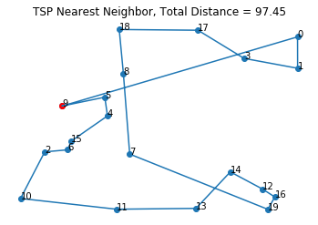

```python
for j in [0, 5, 9]:
    route, total_distance = nearest_neighbor(N,arr,j)
    x_plot = [arr[i,0] for i in route]
    y_plot = [arr[i,1] for i in route]
    plt.figure()
    plt.scatter(arr[:,0], arr[:,1])
    plt.scatter(arr[j,0], arr[j,1], color = "red")
    for i, txt in enumerate(n):
        plt.annotate(txt, (arr[i,0], arr[i,1]))
    plt.plot(x_plot,y_plot)
    plt.axis('off')
    plt.title("TSP Nearest Neighbor, Total Distance = " + str(round(total_distance,2)))
```

```python
def best_NN(arr,N,display):
    if display == True:
        T = PrettyTable()
        T.field_names = ["Starting Node", "Distance"]
    best_route_distance = math.inf
    total_distance_list = []
    start = timeit.default_timer()
    for i in range(N):
        r, d = nearest_neighbor(N,arr,i)
        if display == True:
            T.add_row([i,round(d,2)])
        if d < best_route_distance:
            best_route_distance = d
            best_route = r
    stop = timeit.default_timer()
    run_time = stop-start
    print(T)
    return best_route, best_route_distance, run_time

best_route, best_route_distance, run_time = best_NN(arr,N,True)
print('Best Route List: ', best_route)
print('RunTime: ', run_time)
```

```
+---------------+----------+
| Starting Node | Distance |
+---------------+----------+
|       0       |  91.06   |
|       1       |   89.4   |
|       2       |  90.57   |
|       3       |  89.58   |
|       4       |  94.65   |
|       5       |  94.62   |
|       6       |  95.66   |
|       7       |  85.97   |
|       8       |  89.58   |
|       9       |  97.45   |
|       10      |  90.57   |
|       11      |  93.07   |
|       12      |  99.54   |
|       13      |  98.14   |
|       14      |   96.3   |
|       15      |  96.01   |
|       16      |  101.13  |
|       17      |  94.82   |
|       18      |  89.58   |
|       19      |  98.13   |
+---------------+----------+
Best Route List:  [7, 4, 5, 8, 18, 17, 3, 1, 0, 14, 12, 16, 19, 13, 11, 10, 2, 6, 15, 9, 7]
RunTime:  0.020500499999798194
```

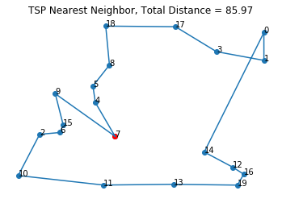

```python
x_plot = [arr[i,0] for i in best_route]
y_plot = [arr[i,1] for i in best_route]
plt.scatter(arr[:,0], arr[:,1])
for i, txt in enumerate(n):
    plt.annotate(txt, (arr[i,0], arr[i,1]))
plt.plot(x_plot,y_plot)
plt.scatter(arr[best_route[0],0], arr[best_route[0],1], color = "red")
plt.axis('off')
plt.title("TSP Nearest Neighbor, Total Distance = " + str(round(best_route_distance,2)))
```